# Stats II: Homework 02

Author

Jerry Eiswerth

Published

September 10, 2025

```r
library(tidyverse)
set.seed(1)
```

## Question 1

### (a)

$ATE=\delta=5$

```r
delta <- 5
```

### (b)

$N=100$

```r
N <- 100
```

### (c)

$Quiz_1$ ~ $N(65, 3)$

```r
mu <- 65
sd <- 3
```

### (d)

Potential Outcomes for $Quiz_2$:
$$y^0=\beta_0+\beta_1x+u_0=10+1.1x+u_0$$
$$y^1=\beta_0+\beta_1x+\delta+u_1=y^1=10+1.1x+\delta+u_1$$
$$u_0, u_1 \sim N(0,1)$$

```r
beta0 <- 10
beta1 <- 1.1
mu1 <- 0
sd1 <- 1
```

### (e)

Now, let’s build the simulated dataset and assign treatment:

```r
d <- tibble(student = 1:N) |>
  # I am randomly assigning half the students to each group,
  # so rather than assigning treatment with probability 0.5,
  # I ensure the even split when sampling.
  mutate(treated = sample(rep(c(0, 1), each = N/2)),
         # Let's draw the quiz 1 values from the normal distribution
         quiz1 = rnorm(N, mean = mu, sd = sd),
         # Draw the error terms from the normal distribution
         u0 = rnorm(N, mean = mu1, sd = sd1),
         u1 = rnorm(N, mean = mu1, sd = sd1),
         # Now create the potential outcome values
         y0 = beta0 + beta1*quiz1 + u0,
         y1 = beta0 + beta1*quiz1 + delta + u1,
         # Create a column for the realized outcome
         quiz2 = ifelse(treated == 1, y1, y0))
```

## (2)

### (a)

$ATE=E[Y^1 -Y^0]=\delta$ represents the average treatment effect, which is the expected difference in potential outcomes if a student was treated vs. not treated, averaged across the entire class. We can also interpret this as the average effect of an extra tutoring session on quiz 2 scores if all students received the extra tutoring session compared to if no students received the extra tutoring session. This means that if every student received the treatment (an extra tutoring session), we would expect them to receive 5 points higher on quiz 2 than if they had not been treated. In this example, the class also represents the population, so we can also interpret $\delta$ as the population average treatment effect (PATE).

### (b)

The intercept for $y^0$ is the expected value for the untreated when the quiz 1 score and the error term are both zero.
$$y^0=\beta_0 + \beta_1x + u_0$$
For $x, u_0 = 0$,
$$y^0=\beta_0$$

The intercept for $y^1$ is the expected value for the treated when the quiz 1 score and the error term are both zero. I interpret this to mean that regardless of the quiz 1 scores and unobserved errors, treatment increases the baseline quiz score by 5 points on average. Graphically, this results in the regression line vertically shifting upwards by 5 points (see Figure 1 below, ignoring the actual slopes).

$$y^1=\beta_0 + \beta_1x + \delta + u_1$$
For $x, u_1 = 0$,
$$y^1=\beta_0 + \delta = \beta_0 + 5$$

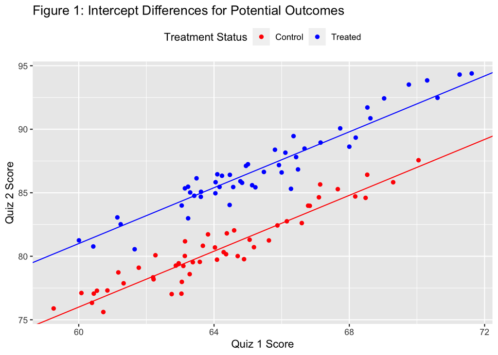

```r
p <- ggplot(data = d,
            aes(x = quiz1,
                y = quiz2,
                color = factor(treated))) +
  geom_point() +
  geom_abline(intercept = beta0, slope = beta1, color = "red") +
  geom_abline(intercept = beta0 + delta, slope = beta1, color = "blue") +
  labs(title = "Figure 1: Intercept Differences for Potential Outcomes",
       x = "Quiz 1 Score",
       y = "Quiz 2 Score") +
  scale_color_manual(values = c("red", "blue"),
                     labels = c("Control", "Treated"),
                     name = "Treatment Status") +
  theme(legend.position = "top")
p
```

### (c)

I interpet $\beta_1$ to be the marginal effect of quiz 1 scores on the predicted value of both $y^0$ and $y^1$. This means that given a 1-point increase in quiz 1 score, I expect on average for the quiz 2 score to increase by 1.1 points, regardless of the treatment status.

## (3)

### (a)

```r
# Because we randomly assigned half the class to each
# treatment status, we know the proportion of each group
# is 0.5.
sate_df <- d |>
  group_by(treated) |>
  summarize(e_y0 = mean(y0),
            e_y1 = mean(y1)) |>
  mutate(cate = e_y1 - e_y0) |>
  summarise(sate = sum(0.5 * cate))

# Extract from dataframe
sate <- sate_df |> pull(sate)

# Compare to the population ATE
print(paste0("SATE = ", sate))
```

```
[1] "SATE = 5.04935398915155"
```

```r
print(paste0("Difference between the SATE and the PATE:", sate - delta))
```

```
[1] "Difference between the SATE and the PATE:0.0493539891515482"
```

The $SATE$ is slightly different from $\delta$, but the magnitude of the difference is very small. We can attribute this difference to the unobserved error terms present in the data generating process, which create variation in the potential outcomes.

### (b)

```r
sate_hat_df <- d |>
  group_by(treated) |>
  summarize(e_y = sum(quiz2)/n()) |>
  mutate(treated = paste0("e_y", treated)) |>
  pivot_wider(names_from = treated, values_from = e_y) |>
  mutate(sate_hat = e_y1 - e_y0)

# Extract from dataframe
sate_hat <- sate_hat_df |> pull(sate_hat)

print(paste0("SATE_hat = ", sate_hat))
```

```
[1] "SATE_hat = 6.40888658310104"
```

```r
print(paste0("SATE_hat - SATE = ", sate_hat - sate))
```

```
[1] "SATE_hat - SATE = 1.35953259394949"
```

Yes, the difference between the $SATE$ and $\widehat{SATE}$ is ~1.36. The estimator $\widehat{SATE}$ is calculated based on the observed, realized outcomes, not both potential outcomes. In contrast, the $SATE$ is calculated using both potential outcomes. Thus, the two measures give us different values. Our simulation also introduced a certain amount of unobserved noise in the error terms, which contributes to the difference in the two values.

### (c)

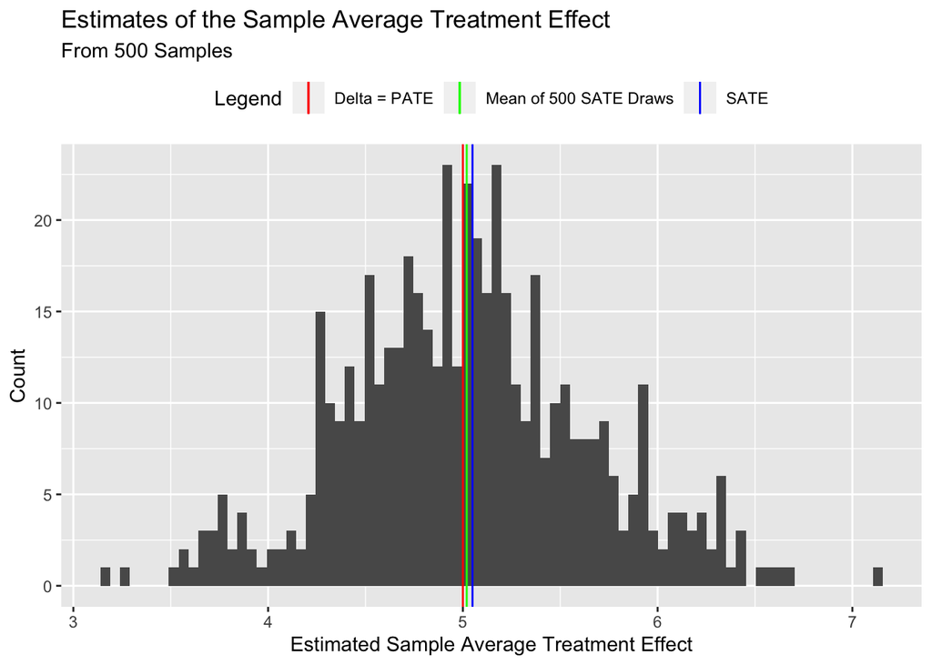

```r
# Create 500 samples
sate_hat_draws <- replicate(500, {
  # Reassign treatment
  treated <- sample(rep(c(0, 1), each = N/2))
  # Calculate observed outcome
  quiz2 = ifelse(treated == 1, d$y1, d$y0)
  # Calculate difference in means
  mean(quiz2[treated == 1]) - mean(quiz2[treated == 0])
})

# Turn into a tibble to use for the plot
sate_hat_draws_df <- tibble(draw = 1:500, sate_hat = sate_hat_draws)

# Add the mean to the dataframe
# (it will give the same value to all observations, but is
# useful for representing the mean graphically)
sate_hat_draws_df <- sate_hat_draws_df |>
  mutate(mean = mean(sate_hat))

# Plot the coefficients
p2 <- ggplot(data = sate_hat_draws_df,
             aes(x = sate_hat)) +
  geom_histogram(bins=80) +
  geom_vline(aes(xintercept = 5,
             color = "Delta = PATE")) +
  geom_vline(aes(xintercept = 5.0493539,
             color = "SATE")) +
  geom_vline(aes(xintercept = mean,
             color = "Mean of 500 SATE Draws")) +
  theme(legend.position = "top") +
  scale_color_manual(name = "Legend",
                     values = c("Delta = PATE" = "red", "SATE" = "blue", "Mean of 500 SATE Draws" = "green")) +
  labs(title = "Estimates of the Sample Average Treatment Effect",
      subtitle = "From 500 Samples",
      y = "Count",
      x = "Estimated Sample Average Treatment Effect")
p2
```

```r
print(paste0("Mean of 500 estimated SATE draws: ", mean(sate_hat_draws_df$sate_hat)))
```

```
[1] "Mean of 500 estimated SATE draws: 5.01979309893061"
```

```r
print(paste0("Standard deviation of 500 estimated SATE draws: ", sd(sate_hat_draws_df$sate_hat)))
```

```
[1] "Standard deviation of 500 estimated SATE draws: 0.627443429009662"
```

### (d)

```r
# Regression 1 - excluding quiz 1 scores
out <- lm(quiz2 ~ treated, data = d)
summary(out)
```

```
Call:
lm(formula = quiz2 ~ treated, data = d)

Residuals:
    Min      1Q  Median      3Q     Max
-6.4275 -1.9636 -0.5535  1.6988  7.4123

Coefficients:
            Estimate Std. Error t value Pr(>|t|)
(Intercept)  80.5712     0.4484  179.69   <2e-16 ***
treated       6.4089     0.6341   10.11   <2e-16 ***
---
Signif. codes:  0 '***' 0.001 '**' 0.01 '*' 0.05 '.' 0.1 ' ' 1

Residual standard error: 3.171 on 98 degrees of freedom
Multiple R-squared:  0.5104,    Adjusted R-squared:  0.5054
F-statistic: 102.1 on 1 and 98 DF,  p-value: < 2.2e-16
```

```r
# Regression 2 - including quiz 1 scores
out2 <- lm(quiz2 ~ treated + quiz1, data = d)
summary(out2)
```

```
Call:
lm(formula = quiz2 ~ treated + quiz1, data = d)

Residuals:
     Min       1Q   Median       3Q      Max
-2.64749 -0.53700  0.07596  0.71076  1.69144

Coefficients:
            Estimate Std. Error t value Pr(>|t|)
(Intercept)  7.57133    2.39353   3.163  0.00208 **
treated      4.90507    0.20167  24.322  < 2e-16 ***
quiz1        1.13891    0.03728  30.550  < 2e-16 ***
---
Signif. codes:  0 '***' 0.001 '**' 0.01 '*' 0.05 '.' 0.1 ' ' 1

Residual standard error: 0.9778 on 97 degrees of freedom
Multiple R-squared:  0.9539,    Adjusted R-squared:  0.953
F-statistic:  1004 on 2 and 97 DF,  p-value: < 2.2e-16
```

When we don’t control for quiz 1 scores, the regression doesn’t account for the fact that students who score higher on quiz 1 are likely to also score higher on quiz 2. Rather, it only uses the treatment variable as a predictor, and naively assumes that variation in quiz 1 scores is grouped into the error term.

If we control for quiz 1 scores as in regression 2, the regression accounts for both treatment and quiz 1 scores in the prediction, reducing variance and producing results that are less noisy and closer to the true value of $\widehat{SATE}$ (4.90507 compared to 5.04935 when holding quiz 1 scores constant). This is true because quiz 1 scores are highly predictive of quiz 2 scores bases on our data-generating process.

### (e)

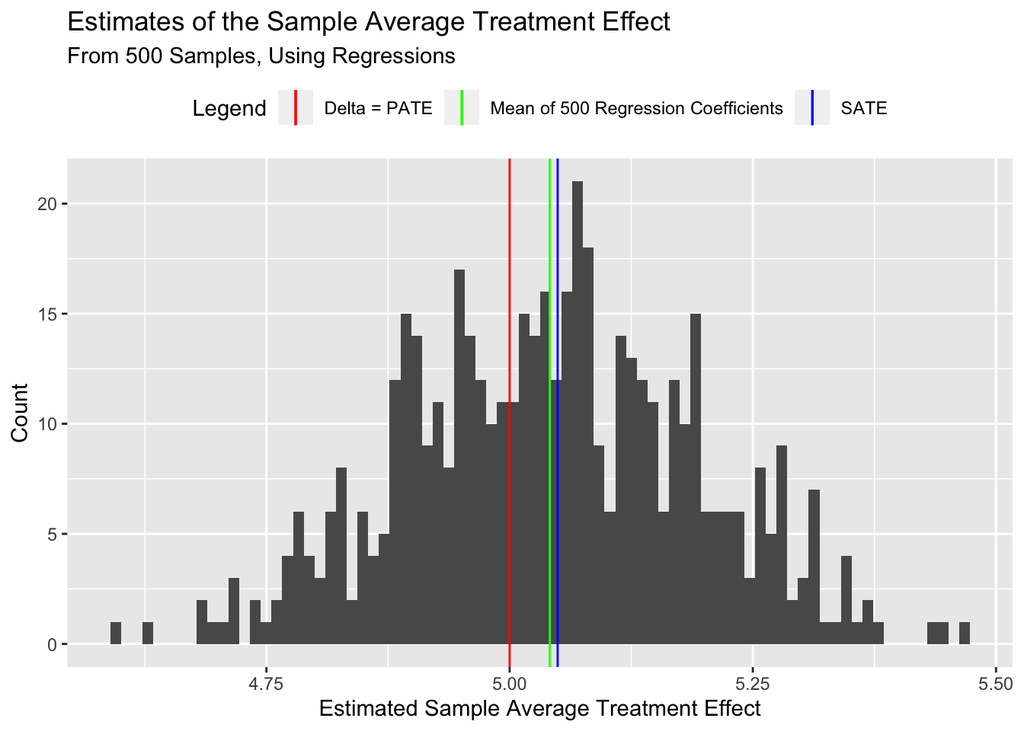

```r
# Create 500 samples
sate_hat_draws2 <- replicate(500, {
  # Reassign treatment
  treated <- sample(rep(c(0, 1), each = N/2))
  # Calculate observed outcome
  quiz2 = ifelse(treated == 1, d$y1, d$y0)
  # Use a temporary dataframe to store values
  temp <- data.frame(quiz2, treated, quiz1 = d$quiz1)
  # Run regression on the subsample
  out <- lm(quiz2 ~ treated + quiz1, data = temp)
  # Extract coefficients
  coef(out)
})

# Turn into a tibble to use for the plot
sate_hat_draws2_df <- as.data.frame(t(sate_hat_draws2))

# Add the mean to the dataframe
# (it will give the same value to all observations, but is
# useful for representing the mean graphically)
sate_hat_draws2_df <- sate_hat_draws2_df |>
  mutate(mean = mean(treated))

# Plot the coefficients
p3 <- ggplot(data = sate_hat_draws2_df,
             aes(x = treated)) +
  geom_histogram(bins=80) +
  geom_vline(aes(xintercept = 5,
             color = "Delta = PATE")) +
  geom_vline(aes(xintercept = 5.0493539,
             color = "SATE")) +
  geom_vline(aes(xintercept = mean,
             color = "Mean of 500 Regression Coefficients")) +
  theme(legend.position = "top") +
  scale_color_manual(name = "Legend",
                     values = c("Delta = PATE" = "red", "SATE" = "blue", "Mean of 500 Regression Coefficients" = "green")) +
  labs(title = "Estimates of the Sample Average Treatment Effect",
      subtitle = "From 500 Samples, Using Regressions",
      y = "Count",
      x = "Estimated Sample Average Treatment Effect")
p3
```

```r
print(paste0("Mean of 500 estimated SATE from regressions: ", mean(sate_hat_draws2_df$treated)))
```

```
[1] "Mean of 500 estimated SATE from regressions: 5.04129265828731"
```

```r
print(paste0("Standard deviation of 500 estimated SATE from regressions: ", sd(sate_hat_draws2_df$treated)))
```

```
[1] "Standard deviation of 500 estimated SATE from regressions: 0.150331552803123"
```

Now, we compare the distribution from using regressions with the quiz 1 scores as a predictor and the simple difference in means: Our true $SATE$ is 5.04935. Using the difference in means, the mean $\widehat{SATE}=5.0198$ and standard deviation = $0.6274$. Whereas, using the regression with quiz 1 controls gives mean $\widehat{SATE}=5.0413$ and standard deviation = $0.1503$. Clearly, when we control for quiz 1 scores, we see a smaller variance and more precise estimates. As such, the regression with control method is preferred.